# Case Study: Stock Portfolio Allocation, Part 1

PSTAT 134 (Winter 2026)

Author

Affiliation

Sang-Yun Oh

University of California, Santa Barbara

## Stock Prices vs. Returns

- Model stock returns as random variables
- Returns depend on change in stock prices:
  $$R_t = \frac{P_t - P_{t-1}}{P_{t-1}} = \frac{P_t}{P_{t-1}} - 1$$
- Linear approximation of $\log(1+x)\approx x$ when $x$ is small.
- Since daily stock returns are small,
  $$R_t \approx \log(1 + R_t) = \log\left(\frac{P_t}{P_{t-1}}\right) = \log(P_t) - \log(P_{t-1})$$
- Compute the log-returns then difference of log prices (converting data)

## Two-asset Portfolio: Bivariate Normal Returns

- Returns of stocks $A$ and $B$ as random variables $R = (R_A, R_B)^T$
- Bivariate normal distribution:
  $$R \sim N(\mu, \Sigma)$$
  where
  $$\begin{aligned}
  \mu =
  \begin{pmatrix}
  \mu_A\\ \mu_B
  \end{pmatrix},\;
  \Sigma =
  \begin{pmatrix}
  \sigma_A^2 & \sigma_{AB}\\
  \sigma_{AB} & \sigma_B^2
  \end{pmatrix}
  \end{aligned}$$
- Marginal distributions:
  $$R_A \sim N(\mu_A,\sigma_A^2) \text{, } R_B \sim N(\mu_B,\sigma_B^2),$$

## Two-asset Portfolio: Modeling Portfolio Returns

- Two-stock portfolio: Return for the portfolio $R_p$ is
  $$R_p = R_A w_A + R_B w_B,$$
- Allocations: $w_A$ and $w_B$ are proportions of stocks $A$ and $B$ such that
  $$w_A + w_B = 1$$
- Note that $w_A$ and $w_B$ can be negative, called short selling
- Optionally, set positivity constraints on $w_A$ and $w_B$.
  $$w_A \geq 0, w_B \geq 0$$

## Two-asset Portfolio: Portfolio Return Distribution

- $R_p$ is also normally distributed with mean $\mu_p$:
  $$\begin{aligned}
  \mu_p &= \text{E}(R_p) = \text{E}(R_A)\, w_A + \text{E}(R_B)\, w_B = \mu_A w_A + \mu_B w_B
  \end{aligned}$$
- And variance $\sigma_p^2$:
  $$\begin{aligned}
  \sigma_p^2 &= \text{Var}(R_p) = \text{Var}\left(R_A w_A + R_B w_B\right) \\
  &= \text{Var}(R_A w_A) + \text{Var}(R_B w_B) + 2\text{Cov}(R_A w_A, R_B w_B) \\
  &= \sigma_A^2\,w_A^2 + \sigma_B^2\,w_B^2 + 2\sigma_{AB}w_A w_B.
  \end{aligned}$$
  Note that $\sigma_{AB} = \rho_{AB}\sigma_A\sigma_B$.
- Distribution of the portfolio return is $R_p \sim N(\mu_p, \sigma_p^2)$

## Two-asset Portfolio: Hedging Portfolio Risk

- Mean return ($\mu_p$): weighted average of returns
  $$\mu_p = \mu_A w_A + \mu_B w_B$$
- Return variance ($\sigma_p^2$) can be decreased if $\rho<0$
  $$\sigma_p^2 = \sigma_A^2\,w_A^2 + \sigma_B^2\,w_B^2 + 2\rho_{AB}\sigma_A\sigma_B\cdot w_A w_B$$
  Since $\sigma_{AB} = \rho_{AB}\sigma_A\sigma_B$.
- Lowering risk $\sigma_p^2$ using stocks with $\rho_{AB}<0$ is called *hedging*.

## Two-asset Portfolio: Minimum Variance Portfolio

$$\begin{aligned}
\min_{w_A,w_B\in\mathbb{R}}\ \ &\sigma_A^2 w_A^2 + \sigma_B^2 w_B^2 + 2\sigma_{AB} w_A w_B\\
\text{subject to }\ \ &w_A + w_B = 1
\end{aligned}$$

. . .

(Substitution or Lagrange multipliers can be used to solve the problem.)

## Two-asset Portfolio: Simulate Returns

- Let returns of stocks $A$ and $B$ are normally distributed
- Mean $\mu_A$ and $\mu_B$
- Standard deviations $\sigma_A$ and $\sigma_B$ and correlation $\rho_{AB}$.
- Correlation matrix $K$ and standard deviations $D$ are:
  $$K = \begin{bmatrix} 1 & \rho_{AB} \\ \rho_{AB} & 1 \end{bmatrix}, \quad D = \begin{bmatrix} \sigma_A & 0 \\ 0 & \sigma_B \end{bmatrix}$$
- Covariance matrix $\Sigma = DKD$:
  $$\Sigma = DKD = \begin{bmatrix} \sigma_A^2 & \sigma_{AB} \\ \sigma_{AB} & \sigma_B^2 \end{bmatrix}$$

## Two-asset Portfolio: Implement in Python

**Set Parameters for Stock Returns**

```python
mu = np.array([0.2, 0.1]) # mean returns
sd = np.array([0.8, 0.3]) # standard deviations

rho = -0.25   # correlation between stocks A and B
```

**Convenience Functions for Portfolio Simulation**

```python
def calculate_portfolio_returns(weights, returns):
  # Calculate portfolio returns as weighted sum of individual stock returns
  Rp = returns @ weights
  # Concatenate individual returns with portfolio returns as new column
  return pd.concat((returns, pd.DataFrame(Rp, columns=['Portfolio'])), axis=1)

def annualize_returns(returns, trading_days=252):
  # Convert daily returns to annual returns assuming 252 trading days per year
  return (1 + returns)**trading_days - 1

def daily_returns(annual_return, trading_days=252):
  # Convert annual returns to daily returns assuming 252 trading days per year
  return np.exp(np.log(1 + annual_return) / trading_days) - 1

def returns_to_prices(returns, start_price=100):
  # Convert returns to cumulative prices starting from initial price
  prices = start_price * (1 + returns).cumprod()
  return prices
```

**Simulate Returns**

```python
def simulate_returns(means, stddevs, rho=0.25, n=None, date_index=None, seed=42):

  if date_index is None:
    if n is None:
      raise ValueError("One of n or date_index must be provided")
    date_index = (
      pd.date_range(end=pd.Timestamp.today(), periods=n, freq='B')
      .strftime('%Y-%m-%d')
    )
  else:
    n = len(date_index)

  # correlation matrix
  K = np.array([[  1, rho], [rho,   1]])
  sigma = np.diag(stddevs) @ K @ np.diag(stddevs)

  # simulate returns
  np.random.seed(seed)
  R = np.random.multivariate_normal(means, sigma, n)

  R_df = pd.DataFrame(R, columns=['Stock A', 'Stock B'], index=date_index)

  return R_df
```

**Simulate Stock Returns**

```python
# number of days to simulate
ndays = 1000

# Create trading dates for the simulated returns
# `freq`: 'B' - Business day frequency, excludes weekends and holidays
date_index = (
  pd.date_range(end=pd.Timestamp.today(), periods=ndays, freq='B')
  .strftime('%Y-%m-%d')
)

# convert to daily returns
mu = daily_returns(mu)
sd = daily_returns(sd)

R = simulate_returns(mu, sd, rho, n=ndays)
```

**Calculate Portfolio Returns for 50/50 Portfolio**

```python
# simulate portfolio returns
w = np.array([0.5, 0.5])
Rp = calculate_portfolio_returns(w, R)
prices = returns_to_prices(Rp, np.array([100, 100, 100]))
```

## Two-asset Portfolio: Plot Portfolio Returns

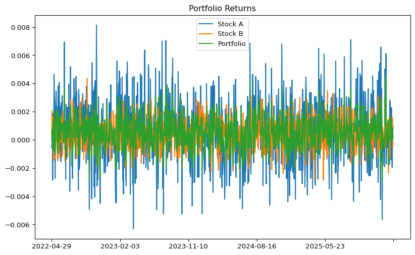

## Two-asset Portfolio: Efficient frontier

- Consider all portfolios: $w_A\in[-0.5,1.5]$ and $w_B=1-w_A$
- For each combination, compute $\mu_p$ and $\sigma_p^2$.

. . .

**Efficient frontier of portfolios**

```python
w_A = np.linspace(-0.5, 1.5, 100)
w_B = 1 - w_A
w_set = np.vstack((w_A, w_B)).T

mu_p = np.dot(w_set, mu)
var_p= np.dot(w_set**2, sd**2) + 2*rho*np.prod(sd)*np.prod(w_set, axis=1)

# Compute MVP allocation using the analytical formula
w_MVP = (sd[1]**2 - rho*sd[0]*sd[1]) / (sd[0]**2 + sd[1]**2 - 2*rho*sd[0]*sd[1])
```

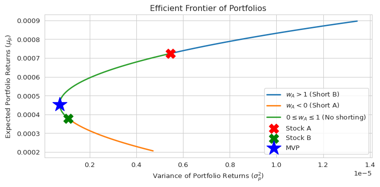

## Two-asset Portfolio: Long and short positions

- Positive $w_A$ : *long position* for stock A and indicates a purchase
- Negative $w_A$ : *short position* stock A and indicates a sale
- Instead of **buying low** and **selling high**,
- Shorting is **selling high** and **buying low**.
- Shorting allows for higher long positions on other stocks.

## Higher Dimensional Portfolio

. . .

- Suppose we have $s$ stocks in the portfolio
- $w = (w_1, w_2, \ldots, w_s)^\intercal$ is the vector of portfolio weights
- $\Sigma$ is $s \times s$ covariance matrix of stock returns
- $\mathbf{1}^\intercal w = 1$, where $\mathbf{1}$ is a vector of ones (fully invested portfolio)

## Minimum Variance Portfolio

A simple version of the problem is,

$$\begin{array}{ll}
\underset{w \in \mathbb{R}^s}{\operatorname{minimize}} & w^\intercal \Sigma w \\
\text { subject to } & \mathbf{1}^\intercal w=1
\end{array}$$

Optimal solution to this problem is (exercise):

$$w^* = (\mathbf{1}^\intercal\Sigma^{-1}\mathbf{1})^{-1}\Sigma^{-1}\mathbf{1}$$

## Minimum Variance Portfolio with Target Return

Minimum variance portfolio is special case of a more general problem
$$\begin{array}{ll}
\underset{w \in \mathbb{R}^s}{\operatorname{minimize}} & w^\intercal \Sigma w \\
\text { subject to } & \mathbf{1}^\intercal w=1\\
& \mu^\intercal w \geq \mu^{*}\\
\end{array}$$

. . .

- Parameters $\mu$ and $\Sigma$ are estimated from data
- User specifies target return $\mu^*$

## Return Maximization with Risk Constraints

Maximize *expected return* with a cap on *level of expected risk*:
$$\begin{array}{ll}
\underset{w \in \mathbb{R}^s}{\operatorname{maximize}} & \mu^\intercal w \\
\text { subject to } & \mathbf{1}^\intercal w=1\\
& w^\intercal \Sigma w \leq\left(\sigma^{*}\right)^2
\end{array}$$

. . .

- Parameters $\mu$ and $\Sigma$ are estimated from data.
- User specifies maximum risk tolerance $\sigma^*$.

## Simulated Portfolio Returns

- Estimate $\hat\mu$ and $\hat\Sigma$ from simulated returns

**Estimate Returns and Volatility from Simulated Data**

```python
mu_hat = R.mean().values
Sigma_hat = R.cov().values
```

- Solve the optimization problems

**Minimum Variance Portfolio**

```python
from cvxpy import Variable, Minimize, Problem

w = Variable(2)
objective = Minimize(cvxpy.quad_form(w, Sigma_hat))
constraints = [cvxpy.sum(w) == 1]
MVP = Problem(objective, constraints)
MVP.solve()

MVP_solution = w.value
MVP_realized_return = mu_hat.T @ MVP_solution
MVP_realized_risk = MVP_solution.T @ Sigma_hat @ MVP_solution
```

**Minimum Variance Portfolio with Target Return**

```python
from cvxpy import Variable, Minimize, Problem

w = Variable(2)
objective = Minimize(cvxpy.quad_form(w, Sigma_hat))
constraints = [cvxpy.sum(w) == 1, mu_hat.T @ w >= 0.00075]
MVP_TR= Problem(objective, constraints)
MVP_TR.solve()

MVP_TR_solution = w.value
MVP_TR_realized_return = mu_hat.T @ MVP_TR_solution
MVP_TR_realized_risk = MVP_TR_solution.T @ Sigma_hat @ MVP_TR_solution
```

**Maximize Return with Risk Constraints**

```python
from cvxpy import Variable, Minimize, Maximize, Problem

w = Variable(2)
objective = Maximize(mu_hat.T @ w)
constraints = [cvxpy.sum(w) == 1, w.T @ Sigma_hat @ w <= 0.000007]
MaxReturn = Problem(objective, constraints)
MaxReturn.solve()

MaxReturn_solution = w.value
MaxReturn_realized_return = mu_hat.T @ MaxReturn_solution
MaxReturn_realized_risk = MaxReturn_solution.T @ Sigma_hat @ MaxReturn_solution
```

## Portfolio Optimization: Summary

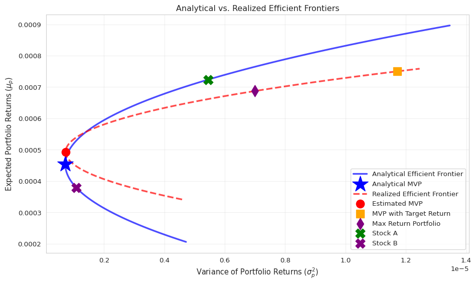

## Practical Considerations in Portfolio Allocation

- Estimating $\mu$ and $\Sigma$ from data
- How do you detect changes in the market conditions?
- How often do you update the estimates?
- How often do you rebalance the portfolio?
- How do you model transaction costs?
- How do you handle short selling?
- Backtesting and out-of-sample performance evaluation